# Authors Data Summary

Lacey Etzkorn

October 10, 2016

## Data Structure

```r
load(file="June_Authors_Data.RData")
library(dplyr)
```

```r
library(ggplot2)
options(width = 90)
summary(user.comment.data)
```

```
##     author           created_utc         likes             score
##  Length:113065      Min.   :1.297e+09   Mode:logical   Min.   :-100.00
##  Class :character   1st Qu.:1.450e+09   NA's:113065    1st Qu.:   1.00
##  Mode  :character   Median :1.464e+09                  Median :   1.00
##                     Mean   :1.454e+09                  Mean   :   5.52
##                     3rd Qu.:1.470e+09                  3rd Qu.:   3.00
##                     Max.   :1.476e+09                  Max.   :4238.00
##       ups              downs   subreddit_id         link_id               id
##  Min.   :-100.00   Min.   :0   Length:113065      Length:113065      Length:113065
##  1st Qu.:   1.00   1st Qu.:0   Class :character   Class :character   Class :character
##  Median :   1.00   Median :0   Mode  :character   Mode  :character   Mode  :character
##  Mean   :   5.52   Mean   :0
##  3rd Qu.:   3.00   3rd Qu.:0
##  Max.   :4238.00   Max.   :0
##      name            parent_id             body
##  Length:113065      Length:113065      Length:113065
##  Class :character   Class :character   Class :character
##  Mode  :character   Mode  :character   Mode  :character
##
##
##
```

```r
summary(user.post.data)
```

```
##     author             title            created_utc            name
##  Length:19097       Length:19097       Min.   :1.145e+09   Length:19097
##  Class :character   Class :character   1st Qu.:1.416e+09   Class :character
##  Mode  :character   Mode  :character   Median :1.450e+09   Mode  :character
##                                        Mean   :1.435e+09
##                                        3rd Qu.:1.466e+09
##                                        Max.   :1.476e+09
##       id            subreddit_id           downs        ups            NA.
##  Length:19097       Length:19097       Min.   :0   Min.   :   0.00   Mode:logical
##  Class :character   Class :character   1st Qu.:0   1st Qu.:   1.00   NA's:19097
##  Mode  :character   Mode  :character   Median :0   Median :   3.00
##                                        Mean   :0   Mean   :  25.45
##                                        3rd Qu.:0   3rd Qu.:   9.00
##                                        Max.   :0   Max.   :6492.00
##   likes             score          num_comments       permalink
##  Mode:logical   Min.   :   0.00   Min.   :    0.00   Length:19097
##  NA's:19097     1st Qu.:   1.00   1st Qu.:    1.00   Class :character
##                 Median :   3.00   Median :    4.00   Mode  :character
##                 Mean   :  25.45   Mean   :   12.04
##                 3rd Qu.:   9.00   3rd Qu.:   10.00
##                 Max.   :6492.00   Max.   :20455.00
##      url              selftext
##  Length:19097       Length:19097
##  Class :character   Class :character
##  Mode  :character   Mode  :character
##
##
##
```

## Authors with no posts

We know that each of these authors had evidence of suicide ideation in June 2016, so we want to make sure that we got data for each of these authors. It is likely that our algorithm for collecting data might have missed some of the users.

```r
no.comments <- authors[!authors %in% user.comment.data$author]
no.comments
```

```
##  [1] "Shodspartan100"       "tw0072"               "tiny-soul"
##  [4] "ImOutsideLookingIn"   "throwaway4710581"     "cb122alt"
##  [7] "generic_names_"       "ireallyneedhelppls1"  "Deathismyonly"
## [10] "I_wanna_kms"          "EngineeringThrow123"  "throwaway1119991"
## [13] "gorbitu34"            "justincasethrowaway3" "gmyheadd"
## [16] "throwaway234655"      "emptylittleworld"     "imsosorry159"
## [19] "fleetingmeaning"      "AnonCry"              "Deletedtomorrow"
## [22] "Imlostandconfused17"  "arg562w73748ty"       "Mearson"
## [25] "odder-otter"          "MoonlightDecay"       "throwmeawaytotheh"
## [28] "trhwr"                "kr620917"             "flowerocity"
## [31] "rrrrrrr666"           "poopybootybutt"       "Laecc"
## [34] "YourNeighbourTotoBro" "kunteh"               "kdnbkvhkbjnl"
## [37] "unnamed1029"          "Destinee0019"         "HaloNariku"
## [40] "sparkk2"              "Wiggisonm"            "RIPzeldaxlove64"
## [43] "garbagelifeexistence" "Lifeisshit1"          "abipolargirl"
## [46] "66544567899665"       "throwswaylo"          "jakenoakes1990"
## [49] "iamtryingthis"        "ikobk"                "SuicidalThanatophobe"
## [52] "realcubagooding"      "behindblueirises"
```

We can see these 53 authors had no recorded comments.

```r
no.posts <- authors[!authors %in% user.post.data$author]
no.posts
```

```
##  [1] "social_retard_225"   "wolfekitten"         "ebrafter"
##  [4] "Amyles98"            "thinpaperwings14"    "Shodspartan100"
##  [7] "NoPointToLife"       "societyexpectations" "miserylovespuppetry"
## [10] "Anonymous-2001"      "ShivatTheMad"        "mylifefucknsux"
## [13] "sourdoughbirb"       "ChevyImpala67"       "Lucasaguiarnf"
```

```r
no.data = intersect(no.posts, no.comments); no.data
```

```
## [1] "Shodspartan100"
```

Overall, we can see 1 authors had no data whatsoever.

## Authors with too many posts

We also know that reddit only allows us to request the most recent 1000 posts or comment from a user, so it is possible that users could have posted so often that we cannot see their record from June. We need to determine whether this is true. We can grab the earliest date from each author.

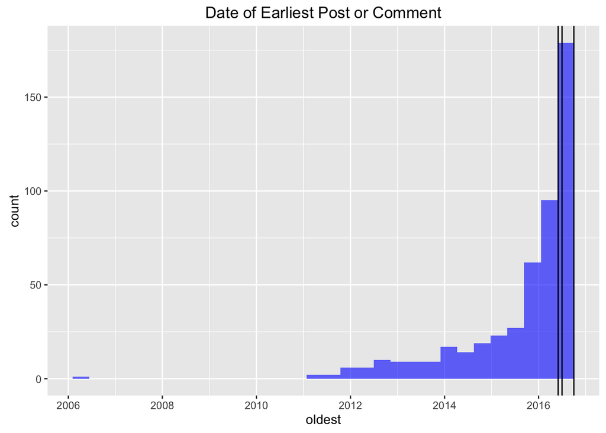

```r
author.post.sum =
      user.post.data %>%
      group_by(author) %>%
      summarise(early.post = min(created_utc),
                n.post = n())
author.comm.sum =
      user.comment.data %>%
      group_by(author) %>%
      summarise(early.comm = min(created_utc),
                n.comm = n())
author.sum =
      merge(author.post.sum, author.comm.sum, by="author", all=T) %>%
      mutate(early.action = pmin(early.post, early.comm, na.rm=T),
             oldest = as.POSIXct(early.action,
                                 origin = "1970-01-01",
                                 tz = "GMT"))
get.date = function(day) as.POSIXct(day, origin = "1970-01-01", tz = "GMT")
july1 = get.date("2016-07-01 00:00:00")
june1 = get.date("2016-06-01 00:00:00")
october1 = get.date("2016-10-01 00:00:00")
jan1 = get.date("2016-01-01 00:00:00")

ggplot(author.sum) +
      geom_histogram(aes(x=oldest), fill="blue", alpha=0.6) +
      geom_vline(aes(xintercept = as.numeric(june1))) +
      geom_vline(aes(xintercept = as.numeric(july1))) +
      geom_vline(aes(xintercept = as.numeric(october1))) +
      ggtitle("Date of Earliest Post or Comment")
```

```r
filter(author.sum, oldest > july1)
```

```
##          author early.post n.post early.comm n.comm early.action              oldest
## 1 NoPointToLife         NA     NA 1470444182   1000   1470444182 2016-08-06 00:43:02
```

```r
filter(author.sum, oldest > june1)[["author"]]
```

```
##   [1] "1861128416"           "23567145675612567"    "4e8967498throwaway"
##   [4] "66544567899665"       "abipolargirl"         "AccioSenpai"
##   [7] "afewmonths"           "aherowithoutaname"    "alcohol-"
##  [10] "Alien_Nicole"         "allaloner"            "Anon6543"
##  [13] "AnonCry"              "Anonymous-2001"       "apparentlypsychotic"
##  [16] "arg562w73748ty"       "ashputtle1"           "awakenmyass"
##  [19] "axledem"              "bayareagay"           "Bechill435"
##  [22] "behindblueirises"     "Bluecheesegrand"      "bozowithme"
##  [25] "breakfast_skipper"    "bunsenturner64"       "buttsoup_jamiecurtis"
##  [28] "cheese_milk"          "Cherokeerlz"          "couldusehelp345"
##  [31] "crisisthrowaway1"     "crosschord"           "Darriushunt"
##  [34] "Deathismyonly"        "Deletedtomorrow"      "Destinee0019"
##  [37] "doggos2cute"          "Donniedarkho"         "dontgiveafuck___"
##  [40] "EaglesDareThere"      "eldrinpaulgok-ong"    "elij1"
##  [43] "emptylittleworld"     "EngineeringThrow123"  "fleetingmeaning"
```

[output cut: 42 more lines]

We see that just one author had too many posts to make it all the way back to June. We will exclude this person from our analysis. Nearly 170 people had their oldest post in June, which may suggest that they also had too many posts, or they began their account in June and have not made more than 1,000 posts since.

## Number of Posts per Author

We can see the joint distribution of posts vs. comments. We can see that 59 people were bumping up against the barrier of 1000 comments and 2 people bumped up against the barrier of 1000 posts.

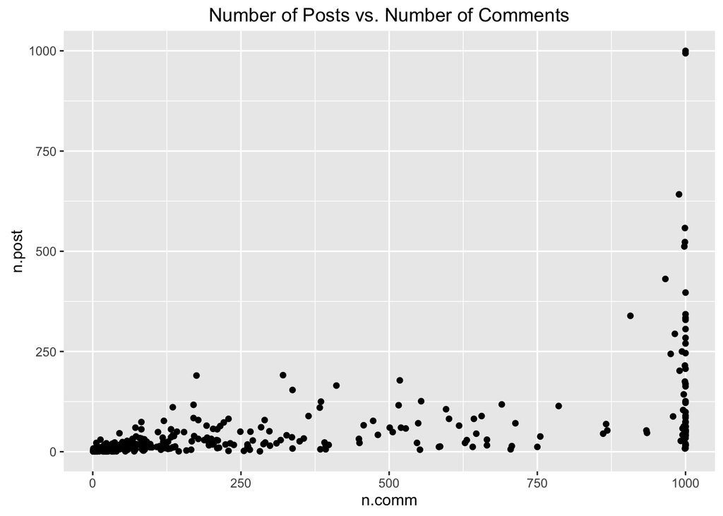

```r
ggplot(author.sum) +
      geom_point(aes(x=n.comm, y=n.post)) +
      ggtitle("Number of Posts vs. Number of Comments")
```

```r
table(author.sum$n.post > 975)
```

```
##
## FALSE  TRUE
##   474     2
```

```r
table(author.sum$n.comm > 975)
```

```
##
## FALSE  TRUE
##   379    59
```

### Does 1000 post limit cut important data?

We need to see whether the limit is going to strongly influence our analysis. For example, it would be great if we can observe all comments made in the 3 months prior to June.

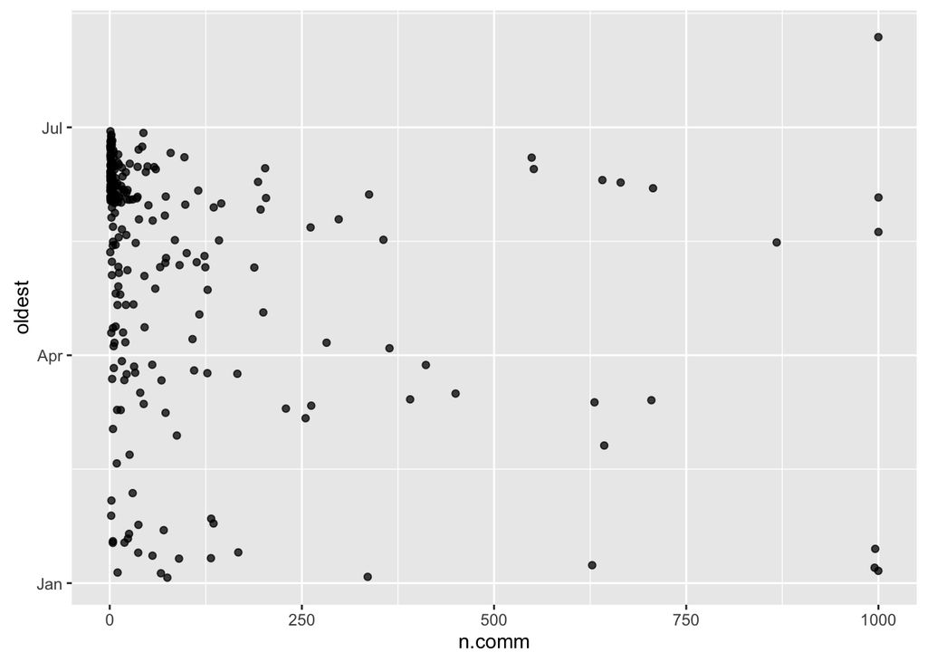

```r
ggplot(filter(author.sum, oldest > jan1)) +
      geom_jitter(aes(x=n.comm, y=oldest), alpha=0.75)
```

This graph shows us that this will only be a problem for three of our users. Two reached their 1000 post limit in late May, and one reached theirs in August. (We already identified this person.)

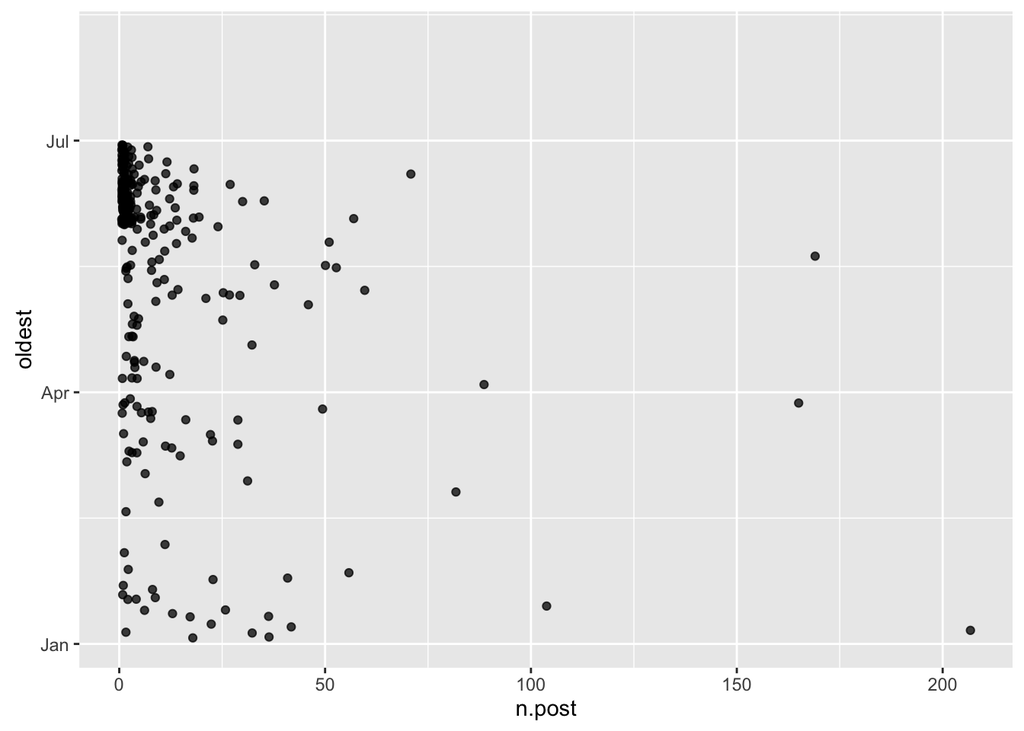

```r
ggplot(filter(author.sum, oldest > jan1)) +
      geom_jitter(aes(x=n.post, y=oldest), alpha=0.75)
```

```r
rm(author.sum, no.comments, no.data, no.posts, author.comm.sum, author.post.sum)
```

### Distribution of Date/Post Times

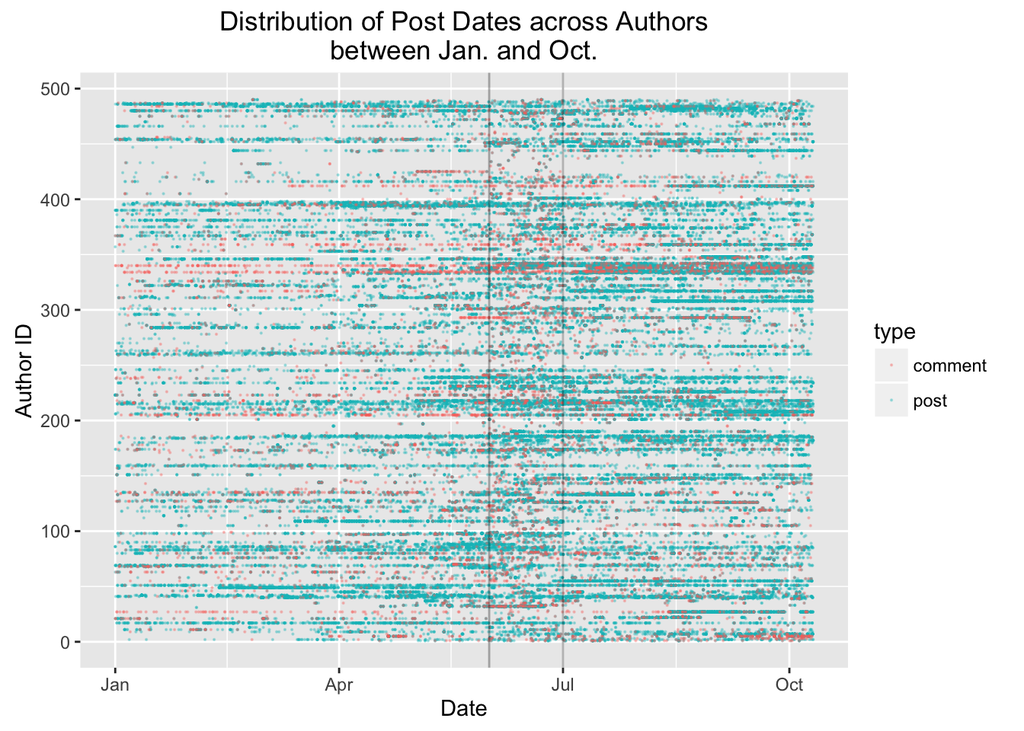

```r
user.data =
      rbind(transmute(user.comment.data, author, subreddit_id,
                      date = get.date(created_utc), type="post"),
            transmute(user.post.data, author, subreddit_id,
                      date = get.date(created_utc), type="comment")) %>%
      mutate(id = as.numeric(as.factor(author)),
             r.depression = subreddit_id=="t5_2qqqf")

ggplot(subset(user.data, date > jan1)) +
      geom_point(aes(y=id, x=date, color=type), alpha=0.3, size=0.1) +
      ggtitle("Distribution of Post Dates across Authors\nbetween Jan. and Oct.") +
      ylab("Author ID") + xlab("Date") +
      geom_vline(aes(xintercept = as.numeric(july1)), alpha=0.3) +
      geom_vline(aes(xintercept = as.numeric(june1)), alpha=0.3)
```

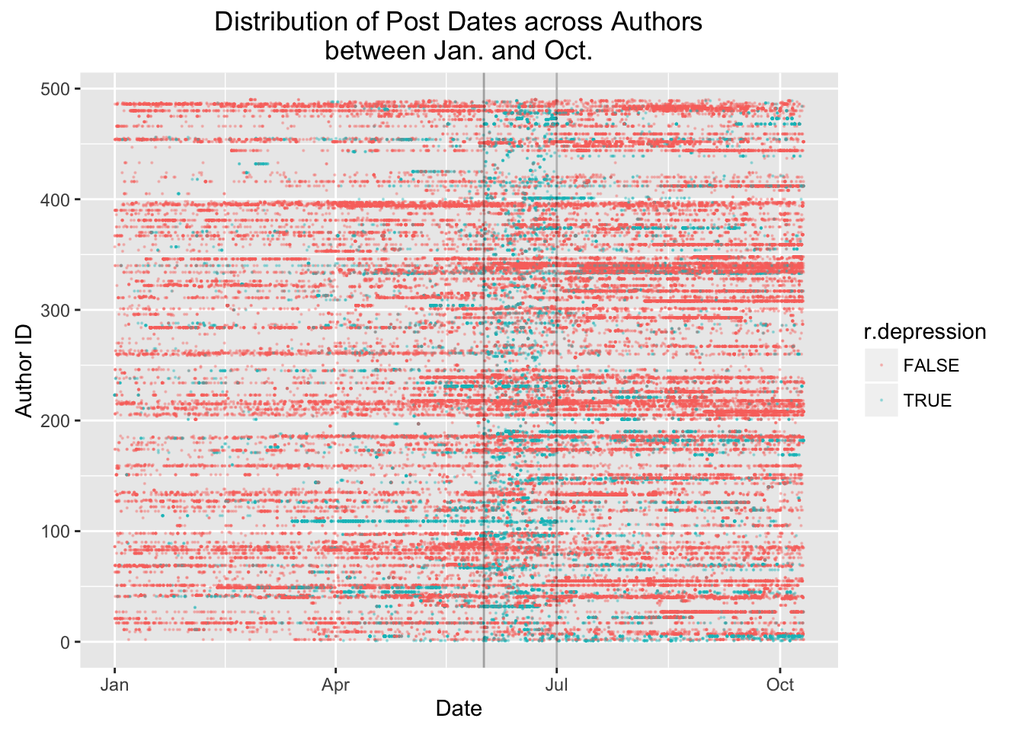

```r
ggplot(subset(user.data, date > jan1)) +
      geom_point(aes(y=id, x=date, color=r.depression), alpha=0.3, size=0.1) +
      ggtitle("Distribution of Post Dates across Authors\nbetween Jan. and Oct.") +
      ylab("Author ID") + xlab("Date") +
      geom_vline(aes(xintercept = as.numeric(july1)), alpha=0.3) +
      geom_vline(aes(xintercept = as.numeric(june1)), alpha=0.3)
```

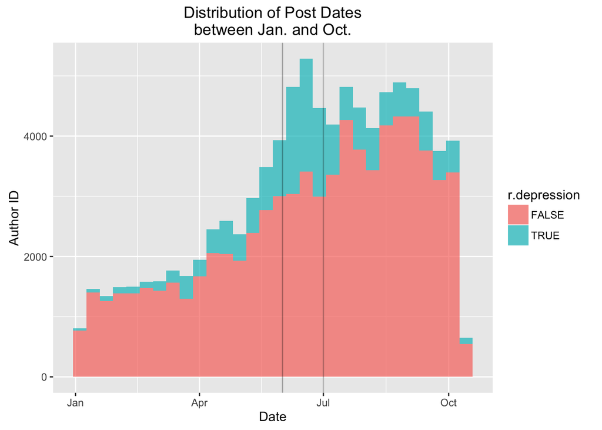

```r
ggplot(subset(user.data, date > jan1)) +
      geom_histogram(aes(x=date, fill=r.depression), alpha=0.7, size=0.1) +
      ggtitle("Distribution of Post Dates\nbetween Jan. and Oct.") +
      ylab("Author ID") + xlab("Date") +
      geom_vline(aes(xintercept = as.numeric(july1)), alpha=0.3) +
      geom_vline(aes(xintercept = as.numeric(june1)), alpha=0.3)
```